# Cálculo del Índice del Desarrollo Humano (IDH) 2020

Programa de las Naciones Unidas para el Desarrollo (PNUD) en México

Diana Villasana Ocampo

## Índice de Desarrollo Humano (`IDH`)

El Índice de Desarrollo Humano (IDH), elaborado por el Programa de las Naciones Unidas para el Desarrollo (PNUD), es una medida compuesta que evalúa el bienestar humano en términos de tres dimensiones principales: salud (esperanza de vida al nacer), educación (años promedio de escolaridad y años esperados de escolaridad), y nivel de vida (ingreso nacional bruto per cápita ajustado por paridad de poder adquisitivo).

En México, el IDH ha sido una herramienta clave para analizar las desigualdades regionales y sociales, así como para orientar las políticas públicas hacia el desarrollo integral. Desde su primera medición, el IDH del país ha mostrado una tendencia general de mejora, aunque las disparidades entre regiones, estados y grupos sociales permanecen significativas.

**Nivel internacional**

[figure not shown]

Fuente: Informe del Desarrollo Humano 2020, (PNUD).

México ha mantenido un nivel de desarrollo humano clasificado como “alto” según los estándares del `PNUD`, aunque está por debajo del promedio de los países más desarrollados. Entre 1990 y 2022, el IDH de México ha crecido de manera sostenida, impulsado principalmente por mejoras en la esperanza de vida y la ampliación del acceso a la educación. Sin embargo, el crecimiento económico, aunque positivo, ha sido moderado y desigual, limitando el impacto de esta dimensión en el índice general.

### Desigualdades regionales

Existen marcadas diferencias en el `IDH` entre las entidades federativas y regiones del país. Estados como Nuevo León, Ciudad de México y Querétaro suelen registrar valores de IDH comparables a los de países desarrollados, mientras que entidades del sur como Chiapas, Oaxaca y Guerrero presentan niveles significativamente más bajos. Estas desigualdades reflejan brechas históricas en infraestructura, acceso a servicios básicos y oportunidades económicas.

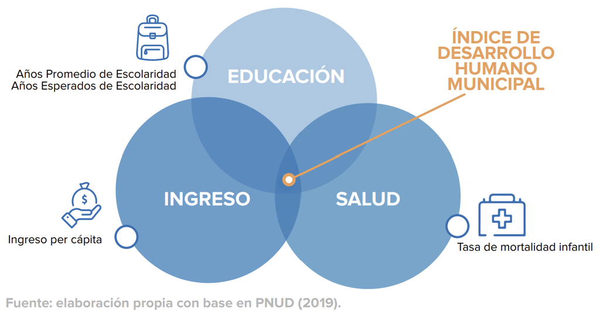

Fuente: Informe del Desarrollo Humano municipal 2010 - 2020, (PNUD).

**Estrategias**

Para abordar estas desigualdades, las estrategias gubernamentales y el PNUD han destacado como prioritario:

- Invertir en educación de calidad, especialmente en las regiones más rezagadas.
- Implementar políticas de salud inclusivas y efectivas.
- Fortalecer programas contra la pobreza con enfoques específicos por territorio y población.
- Impulsar la creación de empleos formales y bien remunerados.

El Índice de Desarrollo Humano (`IDH`), desarrollado por el Programa de las Naciones Unidas para el Desarrollo (PNUD), es una medida compuesta que evalúa el bienestar y el progreso humano en tres dimensiones clave. El enfoque propuesto establece una perspectiva multidimensional que muestra las condiciones de desarrollo con base en una medición robusta que analiza dimensiones fundamentales del bienestar humano (PNUD, 1990). El IDH analiza tres dimensiones esenciales para el bienestar humano: **la educación, la salud y los ingresos disponibles**.

### Fórmula del `IDH`

El `IDH` se calcula como el promedio geométrico de los índices normalizados de estas tres dimensiones:
$$IDH = \sqrt[3]{I_{\text{salud}} \cdot I_{\text{educación}} \cdot
I_{\text{ingreso}}}$$

Cada dimensión se normaliza en una escala de $0$ a $1$, utilizando valores mínimos y máximos predefinidos, lo que permite comparar diferentes regiones o países.

En México, el PNUD publicó el primer Informe de Desarrollo Humano en 2002; desde entonces, las estimaciones y cálculos del IDH en el país se han fortalecido con su vinculación con diversos cálculos relacionados con otras problemáticas del desarrollo en distintos ámbitos de desagregación territorial, como el género, el mercado laboral, la equidad del gasto público, los derechos sociales y la movilidad social, entre otros.

En el ámbito mundial, este método de cálculo toma como referencia los valores internacionales de los indicadores utilizados para calcular el IDH y sus dimensiones

### Cálculo del subíndice de Educación

El índice de educación combina dos subcomponentes: años promedio de escolaridad ($AP$) y años esperados de escolarización ($AE$):

Donde:
$$I_{AP} = \frac{AP}{AP_{\text{max}}} \quad \text{e} \quad I_{AE} =
\frac{AE}{AE_{\text{max}}}$$

- $AP$: Años promedio de escolaridad.
- $AE$: Años esperados de escolarización.
- $AP_{\text{max}}$: Valor máximo de años promedio (15 años).
- $AE_{\text{max}}$: Valor máximo de años esperados (18 años).

#### Recolección de datos

**Valores máximos y mínimos de referencia:**

```r
ae_maximo = 18
ape_maximo = 15
```

#### Censo de Población y Vivienda 2020

Se utiliza la base completa de la muestra del Cuestionario Ampliado del Censo Consultar el Script `"Censo 2020.Rmd"`.

```r
load(paste0(here::here(), "/Bases/Base Completa Censo de población y vivienda 2020.Rda"))
```

#### Paso 1. Generación de nuevas variables, previo a la recodificación

```r
base_educacion <- base_completa %>%
                   mutate(ASISTEN_R = ASISTEN,
                          ESCOLARI_R = as.numeric(ESCOLARI),
                          NIVACAD_R = as.numeric(NIVACAD),
                          ESCOACUM_R = as.numeric(ESCOACUM))
```

#### Paso 2. Recodificación de los años de escolaridad

```r
base_educacion <- base_educacion %>%
                   mutate(anio = case_when(.$NIVACAD_R == 0 ~ 0,
                                           .$NIVACAD_R == 1 ~ 0,
                                           .$NIVACAD_R == 2 & .$ESCOLARI_R == 1 ~ 1,
                                           .$NIVACAD_R == 2 & .$ESCOLARI_R == 2 ~ 2,
                                           .$NIVACAD_R == 2 & .$ESCOLARI_R == 3 ~ 3,
                                           .$NIVACAD_R == 2 & .$ESCOLARI_R == 4 ~ 4,
                                           .$NIVACAD_R == 2 & .$ESCOLARI_R == 5 ~ 5,
                                           .$NIVACAD_R == 2 & .$ESCOLARI_R > 5 & .$ESCOLARI_R < 99 ~ 6,
                                           .$NIVACAD_R == 3 & .$ESCOLARI_R == 1 ~ 7,
                                           .$NIVACAD_R == 3 & .$ESCOLARI_R == 2 ~ 8,
                                           .$NIVACAD_R == 3 & .$ESCOLARI_R > 2 & .$ESCOLARI_R < 99 ~ 9,
                                           .$NIVACAD_R == 4 & .$ESCOLARI_R == 1 ~ 10,
                                           .$NIVACAD_R == 4 & .$ESCOLARI_R == 2 ~ 11,
                                           .$NIVACAD_R == 4 & .$ESCOLARI_R > 2 & .$ESCOLARI_R < 99 ~ 12,
                                           .$NIVACAD_R == 5 & .$ESCOLARI_R == 1 ~ 10,
                                           .$NIVACAD_R == 5 & .$ESCOLARI_R == 2 ~ 11,
                                           .$NIVACAD_R == 5 & .$ESCOLARI_R == 3 ~ 12,
                                           .$NIVACAD_R == 5 & .$ESCOLARI_R > 3 & .$ESCOLARI_R < 99 ~ 13,
                                           .$NIVACAD_R == 6 ~ 6,
                                           .$NIVACAD_R == 7 & .$ESCOLARI_R == 1 ~ 10,
                                           .$NIVACAD_R == 7 & .$ESCOLARI_R == 2 ~ 11,
                                           .$NIVACAD_R == 7 & .$ESCOLARI_R == 3 ~ 12,
                                           .$NIVACAD_R == 7 & .$ESCOLARI_R > 3 & .$ESCOLARI_R < 99 ~ 13,
                                           .$NIVACAD_R == 8 & .$ESCOLARI_R == 1 ~ 13,
                                           .$NIVACAD_R == 8 & .$ESCOLARI_R == 2 ~ 14,
                                           .$NIVACAD_R == 8 & .$ESCOLARI_R > 2 & .$ESCOLARI_R < 99 ~ 15,
                                           .$NIVACAD_R == 9 & .$ESCOLARI_R == 1 ~ 10,
                                           .$NIVACAD_R == 9 & .$ESCOLARI_R == 2 ~ 11,
                                           .$NIVACAD_R == 9 & .$ESCOLARI_R == 3 ~ 12,
                                           .$NIVACAD_R == 9 & .$ESCOLARI_R > 3 & .$ESCOLARI_R < 99 ~ 13,
                                           .$NIVACAD_R == 10 & .$ESCOLARI_R == 1 ~ 13,
                                           .$NIVACAD_R == 10 & .$ESCOLARI_R == 2 ~ 14,
                                           .$NIVACAD_R == 10 & .$ESCOLARI_R == 3 ~ 15,
                                           .$NIVACAD_R == 10 & .$ESCOLARI_R > 3 & .$ESCOLARI_R < 99 ~ 16,
                                           .$NIVACAD_R == 11 & .$ESCOLARI_R == 1 ~ 13,
                                           .$NIVACAD_R == 11 & .$ESCOLARI_R == 2 ~ 14,
                                           .$NIVACAD_R == 11 & .$ESCOLARI_R == 3 ~ 15,
                                           .$NIVACAD_R == 11 & .$ESCOLARI_R > 3 & .$ESCOLARI_R < 99 ~ 16,
                                           .$NIVACAD_R == 12 & .$ESCOLARI_R < 99 ~ 17,
                                           .$NIVACAD_R == 13 & .$ESCOLARI_R == 1 ~ 17,
                                           .$NIVACAD_R == 13 & .$ESCOLARI_R > 1 & .$ESCOLARI_R < 99 ~ 18,
                                           .$NIVACAD_R == 14 & .$ESCOLARI_R < 99 ~ 18,
                                           .$ESCOACUM == 99 ~ 99))
```

#### Paso 3: Creación de identificadores únicos

```r
base_educacion <- base_educacion %>%
                   mutate(estado = str_pad(.$ENT, width = 2, side = c("left"), pad = "0"),
                          municipio = str_pad(.$MUN, width = 3, side = c("left"), pad = "0")) %>%
                    mutate(CVEGEO = paste0(ENT, MUN))
```

#### Paso 4 CREACIÓN DEL ÍNDICE DE EDUCACIÓN

##### Paso 4a. Creación de los años promedio de escolaridad

```r
base_educacion <- base_educacion %>%
                   mutate(edad_m = ifelse(EDAD == 999, NA, EDAD)) %>%
                    mutate(rango_anios = ifelse(anio < 99, 1, 0))

anios_promedio <- base_educacion %>%
                   filter(edad_m > 24 & rango_anios == 1) %>%
                    group_by(estado, CVEGEO, municipio) %>%
                     summarise(anios = weighted.mean(anio, FACTOR))
```

##### Paso 4b. Creación de la tasa de matriculación y de los años esperados

```r
base_educacion <- base_educacion %>%
                   mutate(asistencia = case_when(.$ASISTEN == 1 ~ 1,
                                                 .$ASISTEN == 3 ~ 0,
                                                 .$ASISTEN == 9 ~ 0,
                                                ),
                          rango = case_when(.$EDAD > 5 & .$EDAD < 25 ~ 1,
                                            TRUE ~ 0),
                          poblacion = FACTOR) %>%
                    mutate(matriculados = .$poblacion * .$asistencia)
```

```r
tasa_matriculacion <- base_educacion %>%
                       filter(rango == 1) %>%
                        group_by(estado, CVEGEO, municipio, EDAD) %>%
                         summarise(poblacion = sum(poblacion, na.rm = T),
                                   matriculados = sum(matriculados, na.rm = T)) %>%
                          mutate(tm = matriculados/poblacion) %>%
                           group_by(CVEGEO) %>%
                            mutate(aesperados = sum(tm)) %>%
                             arrange(CVEGEO)
```

##### Paso 4c. Pegado de las bases de datos para generar el índice

```r
base_IE2020 <- tasa_matriculacion %>%
                select(CVEGEO, aesperados) %>%
                 unique() %>%
                  inner_join(., anios_promedio, by = "CVEGEO")
```

##### Paso 4d. Creación de los índices

```r
POB20 <- readxl::read_excel(paste0(here::here(), "/Bases/Población 2020.xlsx")) %>%
          mutate(CVEGEO = sprintf("%05d", Clave)) %>%
           rename(pob20 = poblacion2020) %>%
            select(CVEGEO, pob20)
```

```r
base_IE2020 <- base_IE2020 %>%
                mutate(IAP = anios/ape_maximo,
                       IAE = aesperados/ae_maximo,
                       IEDU = (IAP + IAE) / 2) %>%
                 ungroup() %>%
                  left_join(POB20, by = "CVEGEO") %>%
                   rename(AP2020 = anios,
                          AE2020 = aesperados,
                          IE_2020 = IEDU) %>%
                    select(CVEGEO, pob20, AP2020, AE2020, IE_2020)
```

```r
writexl::write_xlsx(base_IE2020, paste0(here::here(), "/Bases/RESULTADOS SE 2020.xlsx"))
```

### Cálculo del subíndice de Ingreso

$$I_{\text{ingreso}} = \frac{\ln(\text{INB}) -
\ln(\text{INB}_{\text{min}})}{\ln(\text{INB}_{\text{max}}) -
\ln(\text{INB}_{\text{min}})}$$

Donde:  
- $\text{INB}$: Ingreso nacional bruto per cápita ajustado por paridad de poder adquisitivo (PPA).  
- $\text{INB}_{\text{min}}$: Valor mínimo ($100 USD).  
- $\text{INB}_{\text{max}}$: Valor máximo ($75,000 USD).

#### Paso 1: Recolección de datos externos

```r
inpc_DIC2015 = 89.046818
inpc_NOV2020 = 109.271
inb20 = 22644301.694
ajustePPA = 9.702813
```

```r
#Valores máximos y mínimos de referencia:
ing_maximo = 75000
ing_minimo = 100
#Revisar anexo "Indicadores de referencia IDH"
```

#### Paso 2: Reordenar las bases de datos

```r
ictpc_20 <- read_excel(paste0(here::here(), "/Bases/ICTP2020_CONEVAL.xlsx"), skip = 1)

colnames(ictpc_20) <- c("CVE_ENT",
                        "NOM_ENT",
                        "CVEGEO",
                        "NOM_MUN",
                        "ICTPC20")

ictpc_20 <- ictpc_20 %>%
             mutate(ICTPC20 = as.numeric(.$ICTPC20))

POB_20 <- read_excel(paste0(here::here(), "/Bases/Población 2020.xlsx")) %>%
           mutate(Clave = sprintf("%05d", Clave))

colnames(POB_20) <- c("CVEGEO",
                      "NOM_MUN",
                      "POB20")

ictpc_20 <- ictpc_20 %>%
              full_join(., POB_20, by = "CVEGEO") %>%
               rename_at(vars(ends_with(".x")), ~str_replace(., "\\..$","")) %>%
                select_at(vars(-ends_with(".y")))
```

```r
# 3 municipios no cuentan CON ICTPC calculado por el CONEVAL:
# 07125 Honduras de la Sierra, CHS
# 29048 La Magdalena Tlaltelulco, TLX
# 04012 Seybaplaya, CAM
```

#### Paso3. Índice de ingreso 2020

**Paso 1. Cambio del ICTPC a precios de diciembre de 2015 para mantener la comparación de la serie (2010-2020)**

```r
ajuste_inpc <- inpc_DIC2015 / inpc_NOV2020
```

**Paso 2. Generación del ICTPC anual y ICT por municipio**

```r
ictpc_20 <-  ictpc_20 %>%
              mutate(ICTP20_15 = ICTPC20 * ajuste_inpc) %>%
               mutate(ICTPC20_a = ICTP20_15 * 12,
                      ICT2020 = ICTPC20_a * POB20)
```

**Paso 3. Generación del factor de ajuste utilizando el Ingreso Nacional Bruto (INB)**

```r
#El Agregado del Ingreso Corriente Total a nivel nacional:
ICT20_NACIONAL <- ictpc_20 %>%
                   summarise(sum(ICT2020, na.rm = T)) %>%
                    unlist() %>%
                     unname()
```

```r
#Mientras que el INB 2020 es:
inb20_def <- inb20 * ajuste_inpc  #ajustado a precios de dic2015
```

**Factor de ajuste del ingreso total**

```r
ajuste_inb_20 <- inb20_def * 1000000 / ICT20_NACIONAL
```

```r
ictpc_20 <- ictpc_20 %>%
             mutate(ICTPC_ajustado20 = ICTPC20_a * ajuste_inb_20)
```

**Paso 5. Dividir el ICTPC ajustado entre el Factor de conversión de PPA con respecto al dólar estadounidense,**

```r
ictpc_20 <-  ictpc_20 %>%
              mutate(ING_PPC20 = ICTPC_ajustado20 / ajustePPA)
```

**Paso 6. Crear el índice de Ingreso del IDHM**

```r
II_2020 <- ictpc_20 %>%
            mutate(II_2020 = (log(ING_PPC20) - log(ing_minimo)) / (log(ing_maximo) - log(ing_minimo)))
```

```r
base_II2020 <- II_2020 %>%
                select(CVE_ENT, NOM_ENT, CVEGEO, NOM_MUN, ICTPC20, II_2020, POB20) %>%
                 rename(pob20 = POB20)
```

### Cálculo del Subíndice de Salud

#### Paso 1. Valores máximos y mínimos de referencia:

```r
tmi_minima = 1.54
tmi_maxima = 80.10
```

#### Paso 2. acomodo de las bases de datos para el cálculo de la Tasa de Mortalidad Infantil (TMI).

```r
TMI_20<- read_excel(paste0(here::here(), "/Bases/TMI2020_CONAPO.xlsx"), sheet = 1) %>%
          mutate(TMI_2020 = as.numeric(TMI_2020))
```

**NOTA:** Las poblaciones utilizadas para el cálculo de este subíndice corresponden a las estimaciones de CONAPO, que contiene algunas diferencias con respecto a la publicadas por INEGI en el Censo de Población y Vivienda 2020

```r
POB20 <- read_excel(paste0(here::here(), "/Bases/Población 2020 (CONAPO).xlsx")) %>%
          mutate(CVEGEO = sprintf("%05d", CVEGEO)) %>%
           select(CVEGEO, poblacion2020)
```

##### Regionalización

```r
# cálculo de las poblaciones por región en Oaxaca
regs_oax <- read_excel(paste0(here::here(), "/Bases/Regionalizacion_OAX.xlsx")) %>%
             mutate(CVEGEO = sprintf("%05d", CVEGEO))
```

```r
POB_20regs <- POB20 %>%
               mutate(CVE_ENT = substr(CVEGEO, 1, 2)) %>%
                filter(CVE_ENT == "20") %>%
                 left_join(., regs_oax) %>%
                  group_by(CVE_DIST, NOM_DIST) %>%
                   summarise(poblacion2020 = sum(poblacion2020)) %>%
                    mutate(CVEGEO = as.character(CVE_DIST))
```

```r
TMI_20 <- TMI_20 %>%
           left_join(., POB20, by = "CVEGEO") %>%
            rename(POB_2020 = poblacion2020) %>%
             left_join(.,POB_20regs) %>%
              mutate(POB_2020 = ifelse(is.na(POB_2020), poblacion2020, POB_2020)) %>%
               select(-contains("DIST"), -poblacion2020)
```

#### Paso 3. Índice de Salud 2020

**Paso 1. Expresar la Tasa de mortalidad infantil (TMI) municipal, en términos de SI**

```r
TMI_20$SI_2020 <- 1 - (TMI_20$TMI_2020 / 1000)
```

**Paso 2. Calcular el máximo y mínimo de Supervivencia Infantil (SI) internacional a partir de las TMI de referencia**

```r
TMI_20$SImax <- 1 - (tmi_minima / 1000)
TMI_20$SImin <- 1 - (tmi_maxima / 1000)
```

**Paso 3. Calcular el Índice de Salud**

```r
TMI_20 <- TMI_20 %>%
           mutate(IS_2020 = (SI_2020 - SImin) / (SImax - SImin))
```

```r
base_IS2020 <- TMI_20 %>%
                select(CVE_ENT, CVEGEO, NOM_MUN, TMI_2020, IS_2020)
```

```r
write_xlsx(base_IS2020, paste0(here::here(), "/Bases/RESULTADOS SS 2020.xlsx"))
```

### IDH 2020

Una vez calculados los tres índices, el IDH se obtiene como el promedio geométrico:
$$IDH = \sqrt[3]{I_{\text{salud}} \cdot I_{\text{educación}} \cdot
I_{\text{ingreso}}}$$

Estas fórmulas permiten normalizar cada componente y garantizar comparabilidad entre regiones o países.

```r
indices_oax <- base_II2020 %>%
                full_join(., base_IE2020) %>%
                 filter(CVE_ENT == "20") %>%
                  left_join(., regs_oax) %>%
                   group_by(CVE_DIST, NOM_DIST) %>%
                    summarise(IE_2020   = weighted.mean(x = IE_2020, w = pob20),
                              II_2020   = weighted.mean(x = II_2020, w = pob20),
                              ICTPC2020 = weighted.mean(x = ICTPC20, w = pob20),
                              AP2020    = weighted.mean(x = AP2020, w = pob20),
                              AE2020    = weighted.mean(x = AE2020, w = pob20),
                              pob20     = sum(pob20)) %>%
                                           ungroup() %>%
                                            mutate(CVEGEO = as.character(CVE_DIST))
```

Dado que los subíndices de ingreso y educación se tienen a nivel municipio en Oxaca, pero el subíndice de salud, únicamente se calculó a nivel distrito, se homologan todos los subíndices a nivel distrito para Oaxaca.

**IDH para el estado de Oaxaca (nivel distritos)**

```r
idh_oax <- base_IS2020 %>%
            filter(CVE_ENT == "20") %>%
             left_join(., indices_oax) %>%
              select(-CVE_DIST) %>%
               mutate(IDH_2020 = (IE_2020 * II_2020 * IS_2020)^(1/3)) %>%
                mutate(NOM_ENT = "Oaxaca")
```

**IDH para el resto de los estados (nivel municipio)**

```r
idh_resto <- base_II2020 %>%
              full_join(., base_IE2020) %>%
               left_join(., base_IS2020) %>%
                filter(CVE_ENT != "20") %>%
                 mutate(IDH_2020 = (IE_2020 * II_2020 * IS_2020)^(1/3)) %>%
                  rename(ICTPC2020 = ICTPC20)
```

```r
idh_2020 <- full_join(idh_oax, idh_resto)
```

```r
write_xlsx(idh_2020, paste0(here::here(), "/Bases/RESULTADOS IDH 2020.xlsx"))
```

## Referencias

Informe de Desarrollo Humano Municipal 2010-2020: una década de transformaciones locales en México | Programa De Las Naciones Unidas Para El Desarrollo. (2023). Retrieved January 19, 2025, from https://www.undp.org/es/mexico/publicaciones/informe-de-desarrollo-humano-municipal-2010-2020-una-decada-de-transformaciones-locales-en-mexico-0

```r
sesion_info <- devtools::session_info()
```

This work by **Diana Villasana Ocampo** is licensed under a [Creative Commons Attribution 4.0 International License](http://creativecommons.org/licenses/by/4.0/).